Spotify Practical 2, Group 26 Bilgehan Altan Márton Cserta Tracy Mei Jiarui Tu 2025-05-25

```r
# packages used in our report
library(tidyverse)
library(readr)
library(ggplot2)
library(dplyr)
library(caret)
library(glmnet)
library(leaps)
library(ISLR)
```

```r
# importing the Spotify dataset
spotify <- read_csv("Spotify-2000.csv")
```

# Introduction

In the digital music era, platforms like Spotify use a variety of audio features to describe and categorize songs, ranging from Energy and Danceability to Length (Duration). Understanding how these features relate to a song’s Popularity can provide valuable insights for both artists and music streaming services.

Preliminary exploratory data analysis revealed potential associations: songs with higher Energy and Danceability tend to be more popular, while longer songs may receive fewer plays. These observations lead us to the central research question:

“How do audio features such as Energy, Danceability, and Length influence the Popularity of songs on Spotify?”

## Data

```r
# Inspecting our dataset
head(spotify, 10)
```

```
## # A tibble: 10 × 15
##    Index Title            Artist `Top Genre`  Year Beats Per Minute (BP…¹ Energy
##    <dbl> <chr>            <chr>  <chr>       <dbl>                  <dbl>  <dbl>
##  1     1 Sunrise          Norah… adult stan…  2004                    157     30
##  2     2 Black Night      Deep … album rock   2000                    135     79
##  3     3 Clint Eastwood   Goril… alternativ…  2001                    168     69
##  4     4 The Pretender    Foo F… alternativ…  2007                    173     96
##  5     5 Waitin' On A Su… Bruce… classic ro…  2002                    106     82
##  6     6 The Road Ahead … City … alternativ…  2004                     99     46
##  7     7 She Will Be Lov… Maroo… pop          2002                    102     71
##  8     8 Knights of Cydo… Muse   modern rock  2006                    137     96
##  9     9 Mr. Brightside   The K… modern rock  2004                    148     92
## 10    10 Without Me       Eminem detroit hi…  2002                    112     67
## # ℹ abbreviated name: ¹`Beats Per Minute (BPM)`
## # ℹ 8 more variables: Danceability <dbl>, `Loudness (dB)` <dbl>,
## #   Liveness <dbl>, Valence <dbl>, `Length (Duration)` <dbl>,
## #   Acousticness <dbl>, Speechiness <dbl>, Popularity <dbl>
```

```r
summary(spotify)
```

```
##      Index           Title              Artist           Top Genre
##  Min.   :   1.0   Length:1994        Length:1994        Length:1994
##  1st Qu.: 499.2   Class :character   Class :character   Class :character
##  Median : 997.5   Mode  :character   Mode  :character   Mode  :character
##  Mean   : 997.5
##  3rd Qu.:1495.8
##  Max.   :1994.0
##       Year      Beats Per Minute (BPM)     Energy        Danceability
##  Min.   :1956   Min.   : 37.0          Min.   :  3.00   Min.   :10.00
##  1st Qu.:1979   1st Qu.: 99.0          1st Qu.: 42.00   1st Qu.:43.00
##  Median :1993   Median :119.0          Median : 61.00   Median :53.00
##  Mean   :1993   Mean   :120.2          Mean   : 59.68   Mean   :53.24
##  3rd Qu.:2007   3rd Qu.:136.0          3rd Qu.: 78.00   3rd Qu.:64.00
##  Max.   :2019   Max.   :206.0          Max.   :100.00   Max.   :96.00
##  Loudness (dB)        Liveness        Valence      Length (Duration)
##  Min.   :-27.000   Min.   : 2.00   Min.   : 3.00   Min.   :  93.0
##  1st Qu.:-11.000   1st Qu.: 9.00   1st Qu.:29.00   1st Qu.: 212.0
##  Median : -8.000   Median :12.00   Median :47.00   Median : 245.0
##  Mean   : -9.009   Mean   :19.01   Mean   :49.41   Mean   : 262.4
##  3rd Qu.: -6.000   3rd Qu.:23.00   3rd Qu.:69.75   3rd Qu.: 289.0
##  Max.   : -2.000   Max.   :99.00   Max.   :99.00   Max.   :1412.0
##   Acousticness    Speechiness       Popularity
##  Min.   : 0.00   Min.   : 2.000   Min.   : 11.00
##  1st Qu.: 3.00   1st Qu.: 3.000   1st Qu.: 49.25
##  Median :18.00   Median : 4.000   Median : 62.00
##  Mean   :28.86   Mean   : 4.995   Mean   : 59.53
##  3rd Qu.:50.00   3rd Qu.: 5.000   3rd Qu.: 71.00
##  Max.   :99.00   Max.   :55.000   Max.   :100.00
```

The Spotify dataset consists of 1994 observations (songs), containing song attributes and popularity (ranging from 11 to 100).

```r
# renaming variables to avoid errors with spaces
spotify <- spotify %>%
  mutate(BPM = `Beats Per Minute (BPM)`, .keep = "unused") %>%
  mutate(Length = `Length (Duration)`, .keep = "unused") %>%
  mutate(Loudness = `Loudness (dB)`, .keep = "unused")
```

# Exploratory graphs

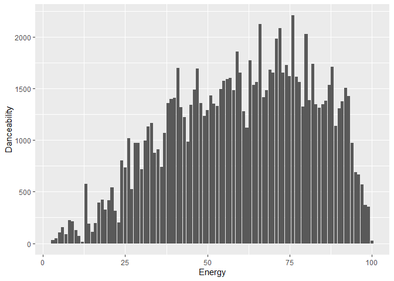

```r
ggplot(spotify, aes(x = Energy, y = Danceability))+
  geom_col()
```

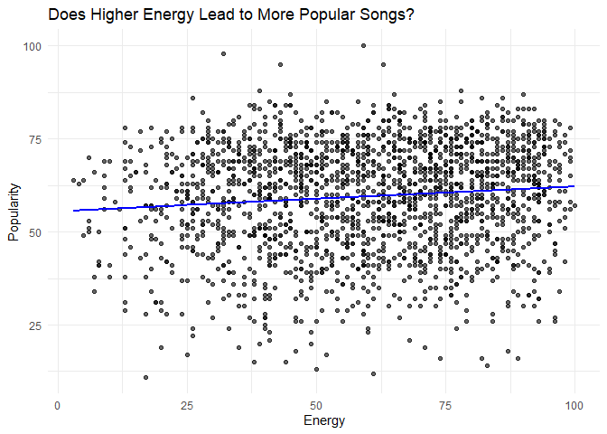

```r
ggplot(spotify, aes(x = Energy, y = Popularity)) +
  geom_point(alpha = 0.6) +
  geom_smooth (method= 'lm', se = FALSE, color = "blue") +
  labs(title = "Does Higher Energy Lead to More Popular Songs?",
       x = "Energy",
       y = "Popularity") +
  theme_minimal()
```

```r
#this one is comparing Energy and Popularity. so as we can see, popularity increases as energy level increase.
```

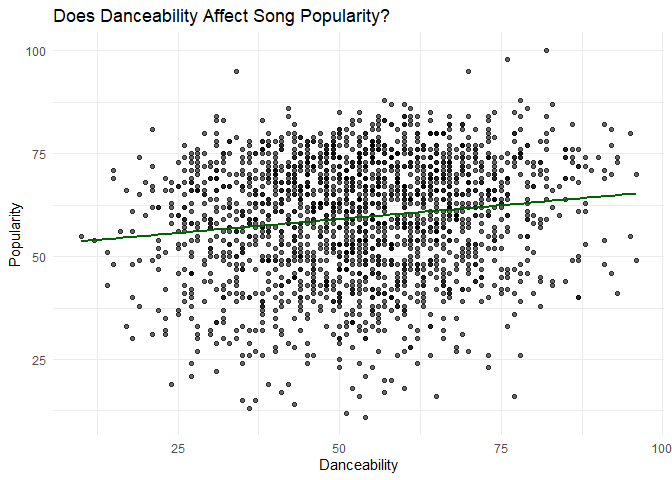

```r
ggplot(spotify, aes(x = Danceability, y = Popularity)) +
  geom_point(alpha = 0.6) +
  geom_smooth(method = "lm", se = FALSE, color = "darkgreen") +
  labs(title = "Does Danceability Affect Song Popularity?",
       x = "Danceability", y = "Popularity") +
  theme_minimal()
```

```r
#This one compares danceability and popularity. it also show us same relationship with energy
```

As can be seen from the graph, there is a positive correlation between a song’s Energy and Popularity, i.e. songs with higher Energy may be slightly more popular overall.

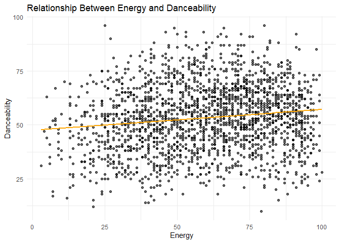

```r
ggplot(spotify, aes(x = Energy, y = Danceability)) +
  geom_point(alpha = 0.6) +
  geom_smooth(method = "lm", se = FALSE, color = "orange") +
  labs(title = "Relationship Between Energy and Danceability",
       x = "Energy", y = "Danceability") +
  theme_minimal()
```

```r
#following code explains the relationship between danceability and energy. there is also a positive relation between them which can be further analysed.
```

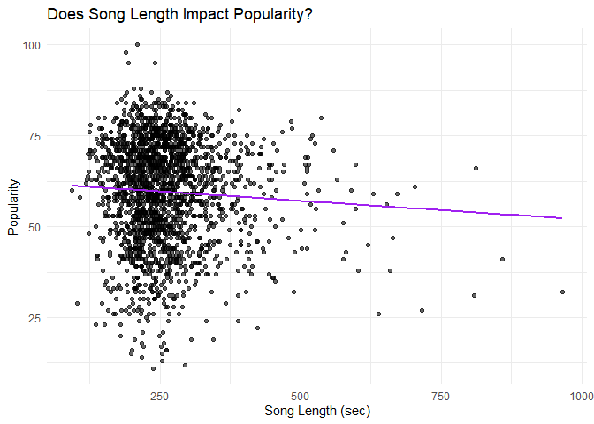

```r
spotify$Length <- as.numeric(spotify$`Length`)

spotify %>%
  filter(`Length` < 1000) %>%
  ggplot(aes(x = `Length`, y = Popularity)) +
    geom_point(alpha = 0.6) +
    geom_smooth(method = "lm", se = FALSE, color = "purple") +
    labs(title = "Does Song Length Impact Popularity?",
         x = "Song Length (sec)", y = "Popularity") +
    theme_minimal()
```

```r
#this one also shows that as song length decrease, popularity increase but we need some tests i think that may not be so valid.
```

The graph shows a slight negative correlation between song length and popularity. That is, shorter songs are more likely to achieve higher popularity overall. This trend is validated by the regression line, which, despite the wide scatter distribution, still shows that longer songs are slightly less popular on the Spotify platform.

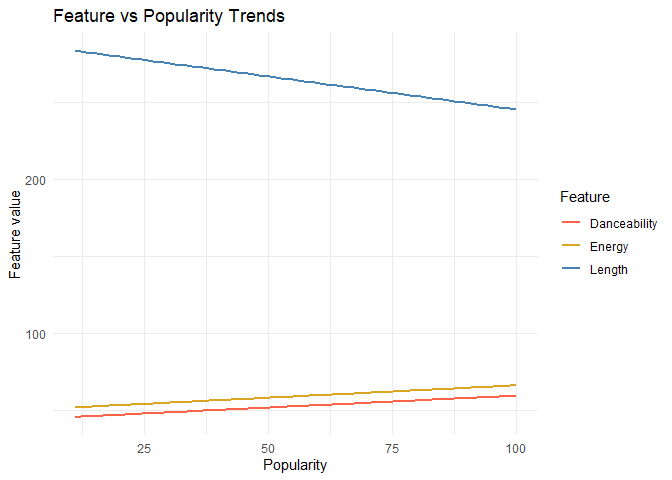

```r
ggplot(spotify) +
  geom_smooth(aes(x = Popularity, y = Energy,       color = "Energy"),       method = "lm", se = FALSE) +
  geom_smooth(aes(x = Popularity, y = Danceability, color = "Danceability"), method = "lm", se = FALSE) +
  geom_smooth(aes(x = Popularity, y = `Length`,      color = "Length"),       method = "lm", se = FALSE) +
  scale_color_manual("Feature",
                     values = c("Energy"="goldenrod",
                                "Danceability"="tomato",
                                "Length"="steelblue")) +
  labs(title = "Feature vs Popularity Trends",
       x     = "Popularity",
       y     = "Feature value") +
  theme_minimal()
```

```r
#everything in one graph. hope it helps. it took like 1 hour to me lol..
```

This graph clearly shows the trend relationship between three audio characteristics and song popularity: Danceability and Energy are positively correlated with popularity, while Length is negatively correlated with popularity. That is, more popular songs tend to be more rhythmic and energetic, but shorter in length.

# Research question

Based on the exploratory data analysis, we observe potential relationships between audio features such as Energy, Danceability, and Length (Duration) with the Popularity of songs on Spotify. The graphs suggest that higher Energy and Danceability may be associated with increased Popularity, while longer song Length might have a negative effect. Therefore, our research question is:

**“How do audio features such as Energy, Danceability, and Length influence the Popularity of songs on Spotify?”**

We will use linear regression to model this relationship and determine which features are the most significant predictors of a song’s popularity.

# Linear Model

## Data Split

We split the data into training (70%), validation (15%), and test (15%) sets to ensure proper model training, selection, and evaluation.

```r
# Set seed for reproducibility
set.seed(123)

# Split data into 70% training, 15% validation, and 15% test
trainIndex <- createDataPartition(spotify$Popularity, p = 0.7, list = FALSE)
train_data <- spotify[trainIndex, ]
temp_data <- spotify[-trainIndex, ]

valIndex <- createDataPartition(temp_data$Popularity, p = 0.5, list = FALSE)
val_data <- temp_data[valIndex, ]
test_data <- temp_data[-valIndex, ]
```

## Model selection

We used two methods for model selection: Lasso regression and best subset selection to identify the best predictors of Popularity.

### Lasso Regression

Lasso regression was performed to select important features by shrinking less relevant coefficients to zero, using all nine predictors to ensure comprehensive feature selection.

```r
# Define predictors
predictors <- c("BPM", "Energy", "Danceability", "Loudness", "Liveness",
                "Valence", "Length", "Acousticness", "Speechiness")

# Prepare model matrices
X_train <- model.matrix(Popularity ~ ., data = train_data[, c("Popularity", predictors)])[ , -1]
y_train <- train_data$Popularity

X_val <- model.matrix(Popularity ~ ., data = val_data[, c("Popularity", predictors)])[ , -1]
y_val <- val_data$Popularity


# Fit Lasso with cross-validation
set.seed(123)  # for reproducibility
lasso_cv <- cv.glmnet(X_train, y_train, alpha = 1)

# Optimal lambda
lambda_opt <- lasso_cv$lambda.min
cat("Optimal lambda selected by CV:", round(lambda_opt, 4), "\n")
```

```
## Optimal lambda selected by CV: 0.0264
```

```r
# Coefficient extraction
lasso_coef <- coef(lasso_cv, s = lambda_opt)
coef_df <- data.frame(
  Feature = rownames(lasso_coef),
  Coefficient = as.vector(lasso_coef)
) %>%
  filter(Coefficient != 0 & Feature != "(Intercept)")

cat("Selected predictors by Lasso:\n")
```

```
## Selected predictors by Lasso:
```

```r
print(coef_df)
```

```
##        Feature  Coefficient
## 1          BPM -0.005733445
## 2       Energy -0.062182283
## 3 Danceability  0.075251692
## 4     Loudness  0.768675400
## 5     Liveness -0.126342956
## 6      Valence  0.044669296
## 7       Length -0.004981800
## 8 Acousticness -0.016966382
## 9  Speechiness  0.311178131
```

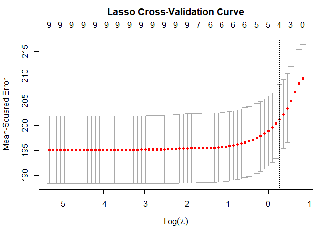

```r
# Plot cross-validation curve
plot(lasso_cv)
title("Lasso Cross-Validation Curve", line = 2.5)
```

Using cross-validation, the optimal regularization parameter was found to be λ = 0.0264, which balances model complexity and predictive performance.

At this optimal λ, the model retained all nine predictors, indicating that each variable contributes meaningfully to the prediction of popularity, although to varying degrees.

The largest coefficients (in absolute value) were associated with:

- Loudness (+0.769): Strongest positive influence, suggesting louder songs tend to be more popular.
- Speechiness (+0.311): Positively related to popularity, potentially reflecting trends in genres with more spoken words (e.g., rap).
- Liveness (−0.126): Negatively associated with popularity, indicating that tracks with a more live performance feel might be less favored by listeners.

Other predictors such as Danceability, Valence, and Energy also contributed with moderate coefficients, while variables like BPM, Length, and Acousticness had relatively small effects.

### Best Subset Selection

```r
#creating a function that calculates the mses
lm_mse <- function(formula, train_data, valid_data) {
  y_name <- all.vars(formula)[1]
  y_true <- valid_data[[y_name]]

  lm_fit <- lm(formula, train_data)
  y_pred <- predict(lm_fit, newdata = valid_data)

  mean((y_true - y_pred)^2)
}
```

```r
# function for generating all formulas for given number of predictors
generate_formulas <- function(p, x_vars, y_var) {
  # Input checking
  if (p %% 1 != 0)           stop("Input an integer n")
  if (p > length(x_vars))    stop("p should be smaller than number of vars")
  if (!is.character(x_vars)) stop("x_vars should be a character vector")
  if (!is.character(y_var))  stop("y_vars should be character type")

  apply(combn(x_vars, p), 2, function(vars) {
    paste0(y_var, " ~ ", paste(vars, collapse = " + "))
  })
}
```

```r
# Selecting relevant (numeric) predictors
predictor_vars <- spotify %>%
  select(-Index, -Title, -Artist, -`Top Genre`, -Year, -Popularity) %>%
  colnames()
predictor_vars
```

```
## [1] "Energy"       "Danceability" "Liveness"     "Valence"      "Acousticness"
## [6] "Speechiness"  "BPM"          "Length"       "Loudness"
```

```r
best_preds <- c()
best_mses <- c()

# Create a dataframe to store results for readability
results_df <- data.frame(
  Num_Predictors = integer(),
  Formula = character(),
  MSE = double(),
  stringsAsFactors = FALSE
)

# repeating for 1 to 9 predictors
for (p in 1:9) {
  # generating formulas
  formulas <- generate_formulas(p = p, x_vars = predictor_vars, y_var = "Popularity")

  # calculating the mses for all models with p predictors
  mses <- rep(0, length(formulas))
  for (i in 1:length(formulas)){
    mses[i] <- lm_mse(as.formula(formulas[i]), train_data, val_data)
  }

  # selecting the best model for p preddictors
  best_preds[p] <- formulas[which.min(mses)]
  best_mses[p] <- min(mses)
}

# selecting the best model and its mse from the best models
best_model <- best_preds[which.min(best_mses)]
best_mse <- min(best_mses)
```

## Model evaluation

We evaluated both models on the validation set using Mean Squared Error (MSE) to determine which performs better.

```r
mse <- function(y_true, y_pred) {
  mean((y_true - y_pred)^2)
}
```

```r
set.seed(123)

# --- Lasso Regression Model Evaluation ---

# Predict Popularity on validation data using the Lasso model with optimal lambda
y_val_pred_lasso <- predict(lasso_cv, s = lambda_opt, newx = X_val)

# Calculate MSE for Lasso predictions on validation set
mse_lasso <- mse(y_val, y_val_pred_lasso)
cat("Validation MSE for Lasso regression:", round(mse_lasso, 4), "\n")
```

```
## Validation MSE for Lasso regression: 203.6253
```

```r
# --- Best Subset Selection Model Evaluation ---

# Fit the best subset selection model (best_model formula) on training data
best_lm <- lm(as.formula(best_model), data = train_data)

# Predict Popularity on validation data using best subset model
y_val_pred_best <- predict(best_lm, newdata = val_data)

# Calculate MSE for best subset model predictions on validation set
mse_best <- mse(val_data$Popularity, y_val_pred_best)
cat("Validation MSE for Best Subset Selection:", round(mse_best, 4), "\n")
```

```
## Validation MSE for Best Subset Selection: 198.6695
```

```r
# --- Summary Table ---

# Create a summary data frame for easy comparison
mse_summary <- data.frame(
  Model = c("Lasso Regression", "Best Subset Selection"),
  Validation_MSE = c(mse_lasso, mse_best)
)

print(mse_summary)
```

```
##                   Model Validation_MSE
## 1      Lasso Regression       203.6253
## 2 Best Subset Selection       198.6695
```

- Lasso Model: The MSE on the validation set was 203.63.
- Best Subset Model: Using the best subset selection, the MSE was 198.67.

The Best Subset Model achieved a slightly lower MSE (198.67 vs. 203.63), indicating marginally better predictive performance on the validation set. Although the difference is small, we selected the Best Subset Model for final evaluation due to its lower MSE.

# Results

## Final Model Evaluation

To evaluate the model’s performance on unseen data, the Best Subset Model was tested on the test set.

```r
# Define predictor variables used in the Best Subset Selection model
predictor_vars <- c("Energy", "Danceability", "Liveness", "Valence",
                    "Acousticness", "Speechiness", "BPM", "Length", "Loudness")

# Prepare test set matrix for prediction (remove intercept column if present)
X_test <- model.matrix(~ ., data = test_data[, predictor_vars])[ , -1]
y_test <- test_data$Popularity

# Predict using the Best Subset Selection model
y_test_pred <- predict(best_lm, newdata = test_data[, predictor_vars])

# Calculate Mean Squared Error on the test set
mse_test <- mean((y_test - y_test_pred)^2)

# Output the result
cat("Test set MSE for Best Subset Selection model:", round(mse_test, 4), "\n")
```

```
## Test set MSE for Best Subset Selection model: 173.2469
```

The test MSE of 173.25 reflects the model’s average squared prediction error on new data, offering insight into its generalization capability.

# Conclusion

Future studies may incorporate a broader set of features and apply nonlinear machine learning methods (e.g., random forests or neural networks) to enhance predictive power. In addition, extending the analysis to other streaming platforms or adding a temporal dimension could offer comparative insights and help capture the dynamics of music popularity over time.

In summary, this study provides a preliminary quantitative foundation for understanding the audio-based drivers of song popularity. While the findings offer potential guidance for recommendation system design and creative production strategies, further research is needed to expand and deepen these insights.

# Contributions

- Tujiarui: Conducting data visualization analysis and writing the Introduction and Conclusion. Summarizing key insights, limitations, and future directions in the report.
- Marton: Using best subset Selection to evaluate models. Formatting and structure.
- Tracy: Generate one research question using linear regression line. Using lasso regression and Best Subset Selection, and Model evaluation.
- Bilgehan: Creating graphs, finding research question by visual analysis through plots.

AI statement: AI tools such as ChatGPT were used only for some code debugging support and writing language polishing.